# Lab09_Mhaske_Aditya

[Run in Google Colab](https://colab.research.google.com/github/yy/dviz-course/blob/master/docs/m09-estimation/lab09.ipynb)

[figure not shown]

View on Github

[figure not shown]

View raw on Github

# Module 9: Estimation

In this lab, we will learn about Kernel Density Estimation (KDE), interpolation, and (briefly) regression.

```python
import matplotlib.pyplot as plt
import numpy as np
import seaborn as sns
import altair as alt
import pandas as pd
import scipy.stats as ss
%matplotlib inline
```

## Kernel density estimation

Let's import the IMDb data.

```python
import vega_datasets

movies = vega_datasets.data.movies()
movies.head()
```

|  | Title | US_Gross | Worldwide_Gross | US_DVD_Sales | Production_Budget | Release_Date | MPAA_Rating | Running_Time_min | Distributor | Source | Major_Genre | Creative_Type | Director | Rotten_Tomatoes_Rating | IMDB_Rating | IMDB_Votes |
| --- | --- | --- | --- | --- | --- | --- | --- | --- | --- | --- | --- | --- | --- | --- | --- | --- |
| 0 | The Land Girls | 146083.0 | 146083.0 | NaN | 8000000.0 | Jun 12 1998 | R | NaN | Gramercy | None | None | None | None | NaN | 6.1 | 1071.0 |
| 1 | First Love, Last Rites | 10876.0 | 10876.0 | NaN | 300000.0 | Aug 07 1998 | R | NaN | Strand | None | Drama | None | None | NaN | 6.9 | 207.0 |
| 2 | I Married a Strange Person | 203134.0 | 203134.0 | NaN | 250000.0 | Aug 28 1998 | None | NaN | Lionsgate | None | Comedy | None | None | NaN | 6.8 | 865.0 |
| 3 | Let's Talk About Sex | 373615.0 | 373615.0 | NaN | 300000.0 | Sep 11 1998 | None | NaN | Fine Line | None | Comedy | None | None | 13.0 | NaN | NaN |
| 4 | Slam | 1009819.0 | 1087521.0 | NaN | 1000000.0 | Oct 09 1998 | R | NaN | Trimark | Original Screenplay | Drama | Contemporary Fiction | None | 62.0 | 3.4 | 165.0 |

Although we have learned that it is dangerous to drop any missing values, we will do so for the sake of simplicity. We are also really not trying to draw any conclusions about the data so it is okay. But be careful with missing data in practice!

**Q: Can you drop rows that have NaN value in either `IMDB_Rating` or `Rotten_Tomatoes_Rating`?**

```python
# YOUR SOLUTION HERE
movies = movies.dropna(subset=['IMDB_Rating', 'Rotten_Tomatoes_Rating'])
movies
```

|  | Title | US_Gross | Worldwide_Gross | US_DVD_Sales | Production_Budget | Release_Date | MPAA_Rating | Running_Time_min | Distributor | Source | Major_Genre | Creative_Type | Director | Rotten_Tomatoes_Rating | IMDB_Rating | IMDB_Votes |
| --- | --- | --- | --- | --- | --- | --- | --- | --- | --- | --- | --- | --- | --- | --- | --- | --- |
| 4 | Slam | 1009819.0 | 1087521.0 | NaN | 1000000.0 | Oct 09 1998 | R | NaN | Trimark | Original Screenplay | Drama | Contemporary Fiction | None | 62.0 | 3.4 | 165.0 |
| 8 | Pirates | 1641825.0 | 6341825.0 | NaN | 40000000.0 | Jul 01 1986 | R | NaN | None | None | None | None | Roman Polanski | 25.0 | 5.8 | 3275.0 |
| 9 | Duel in the Sun | 20400000.0 | 20400000.0 | NaN | 6000000.0 | Dec 31 2046 | None | NaN | None | None | None | None | None | 86.0 | 7.0 | 2906.0 |
| 10 | Tom Jones | 37600000.0 | 37600000.0 | NaN | 1000000.0 | Oct 07 1963 | None | NaN | None | None | None | None | None | 81.0 | 7.0 | 4035.0 |
| 11 | Oliver! | 37402877.0 | 37402877.0 | NaN | 10000000.0 | Dec 11 1968 | None | NaN | Sony Pictures | None | Musical | None | None | 84.0 | 7.5 | 9111.0 |
| ... | ... | ... | ... | ... | ... | ... | ... | ... | ... | ... | ... | ... | ... | ... | ... | ... |
| 3195 | Zombieland | 75590286.0 | 98690286.0 | 28281155.0 | 23600000.0 | Oct 02 2009 | R | 87.0 | Sony Pictures | Original Screenplay | Comedy | Fantasy | Ruben Fleischer | 89.0 | 7.8 | 81629.0 |
| 3196 | Zack and Miri Make a Porno | 31452765.0 | 36851125.0 | 21240321.0 | 24000000.0 | Oct 31 2008 | R | 101.0 | Weinstein Co. | Original Screenplay | Comedy | Contemporary Fiction | Kevin Smith | 65.0 | 7.0 | 55687.0 |
| 3198 | Zoom | 11989328.0 | 12506188.0 | 6679409.0 | 35000000.0 | Aug 11 2006 | PG | NaN | Sony Pictures | Based on Comic/Graphic Novel | Adventure | Super Hero | Peter Hewitt | 3.0 | 3.4 | 7424.0 |
| 3199 | The Legend of Zorro | 45575336.0 | 141475336.0 | NaN | 80000000.0 | Oct 28 2005 | PG | 129.0 | Sony Pictures | Remake | Adventure | Historical Fiction | Martin Campbell | 26.0 | 5.7 | 21161.0 |
| 3200 | The Mask of Zorro | 93828745.0 | 233700000.0 | NaN | 65000000.0 | Jul 17 1998 | PG-13 | 136.0 | Sony Pictures | Remake | Adventure | Historical Fiction | Martin Campbell | 82.0 | 6.7 | 4789.0 |

2260 rows × 16 columns

We can plot histogram and KDE using pandas:

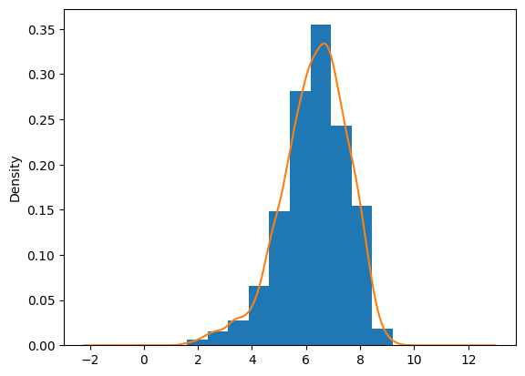

```python
movies['IMDB_Rating'].hist(bins=10, density=True)
movies['IMDB_Rating'].plot(kind='kde')
```

Or using seaborn (two ways):

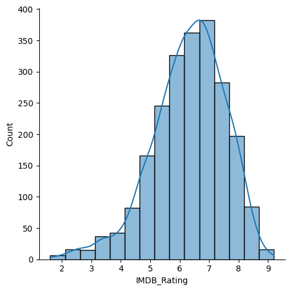

```python
sns.displot(movies['IMDB_Rating'], bins=15, kde=True)
```

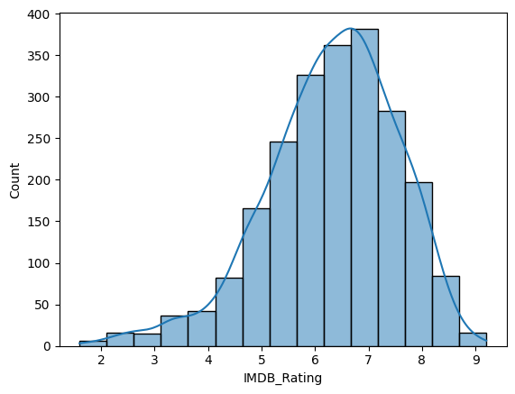

```python
sns.histplot(movies['IMDB_Rating'], bins=15, kde=True)
```

**Q: Can you plot the histogram and KDE of the `Rotten_Tomatoes_Rating`?**

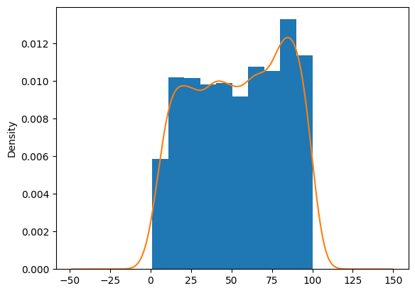

```python
# YOUR SOLUTION HERE
movies['Rotten_Tomatoes_Rating'].hist(bins=10, density=True)
movies['Rotten_Tomatoes_Rating'].plot(kind='kde')
plt.show()
```

Let's study how KDE changes with the size of the data.

We can get a random sample using the pandas' [**`sample()`**](https://pandas.pydata.org/pandas-docs/stable/reference/api/pandas.DataFrame.sample.html) function. The [**`kdeplot()`**](https://seaborn.pydata.org/generated/seaborn.kdeplot.html) function in seaborn provides many options (like kernel types) to do KDE. Let's sample some data points and see how does KDE plot changes with the size of the samples.

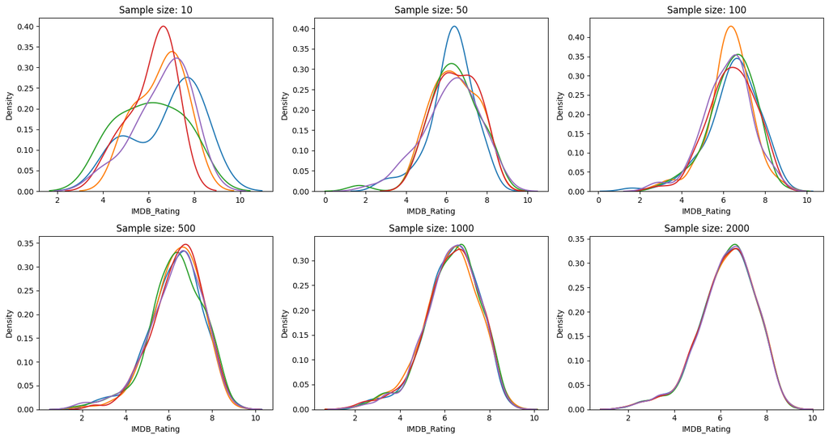

```python
f = plt.figure(figsize=(15,8))
plt.xlim(0, 10)

sample_sizes = [10, 50, 100, 500, 1000, 2000]
for i, N in enumerate(sample_sizes, 1):
    plt.subplot(2,3,i)
    plt.title("Sample size: {}".format(N))
    for j in range(5):
        s = movies['IMDB_Rating'].sample(N)
        sns.kdeplot(s, legend=False)
plt.tight_layout()
```

We can also draw KDE plots using scikit-learn to change kernel functions.

First, we need points to score across.

- Remember the np.linspace() function?
- IMDB scores are only between 1 and 10. Let's create 1000 points between 1 and 10.

```python
# use the linespace function to create a list of 1000 values
# between 1 and 10
# Store the sequence in a variable called X_vals

# YOUR SOLUTION HERE
X_vals = np.linspace(1, 10, 1000)
X_vals[0:10]
```

```
array([1.        , 1.00900901, 1.01801802, 1.02702703, 1.03603604,
       1.04504505, 1.05405405, 1.06306306, 1.07207207, 1.08108108])
```

```python
X_vals.shape
```

```
(1000,)
```

Our array needs to have 2 dimensions for score_samples() to work. Let's add another dimension to our array using np.newaxis.

```python
X_plot = X_vals[:, np.newaxis]
X_plot[0:10]
```

```
array([[1.        ],
       [1.00900901],
       [1.01801802],
       [1.02702703],
       [1.03603604],
       [1.04504505],
       [1.05405405],
       [1.06306306],
       [1.07207207],
       [1.08108108]])
```

```python
X_plot.shape
```

```
(1000, 1)
```

The KernelDensity function in scikit-learn needs a 2d array for the samples when we fit to the different kernels. Multidimensional scaling is deprecated for pandas series. We can cast the series to a numpy array before adding another dimension to solve this issue.

```python
sample = movies['IMDB_Rating'].sample(5)
print(sample)
print(type(sample))
print(sample.shape)
```

```
2744    5.9
2017    5.4
2929    7.5
1761    7.8
1799    6.3
Name: IMDB_Rating, dtype: float64
<class 'pandas.core.series.Series'>
(5,)
```

```python
sample = np.array(sample)
print(sample)
print(type(sample))
print(sample.shape)
```

```
[5.9 5.4 7.5 7.8 6.3]
<class 'numpy.ndarray'>
(5,)
```

```python
# Add another dimension to sample using np.newaxis
# Just like we did to X_vals.

# YOUR SOLUTION HERE

sample_2d = sample[:, np.newaxis]
sample_2d
```

```
array([[5.9],
       [5.4],
       [7.5],
       [7.8],
       [6.3]])
```

Now, let's plot using the **`tophat`** and **`gaussian`** kernels using the different sample sizes we used before. We'll do this using scikit-learn's `KernelDensity()` function.

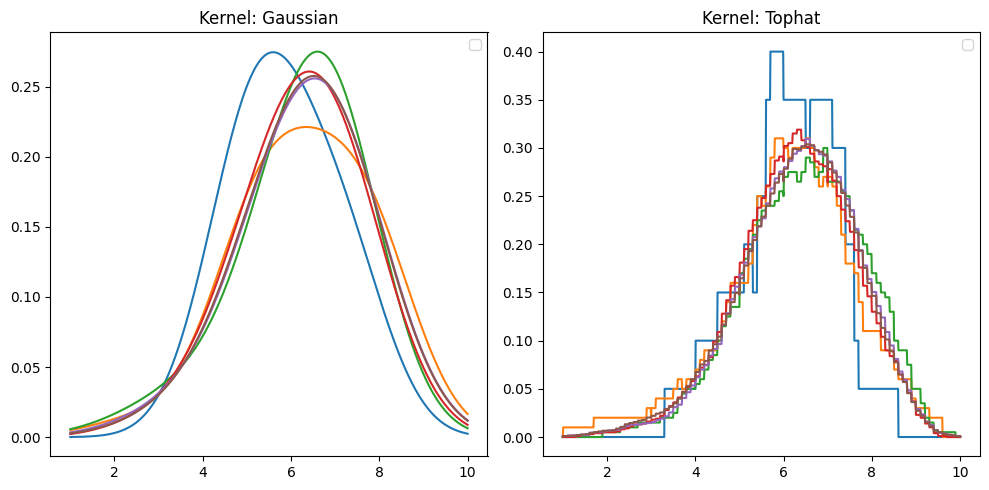

```python
from sklearn.neighbors import KernelDensity
sample_sizes = [10, 50, 100, 500, 1000, 2000]

def plot_kde(X_plot, sample_sizes, movies, kernel='gaussian'):
    for sample_size in sample_sizes:
        sample = np.array(movies['IMDB_Rating'].sample(sample_size))
        sample = sample[:, np.newaxis]
        sample = sample[~np.isnan(sample)]
        sample = sample.reshape(-1, 1)
        kde = KernelDensity(kernel=kernel).fit(sample)
        log_density = kde.score_samples(X_plot)
        plt.plot(X_plot[:, 0], np.exp(log_density), '-')

fig, ax = plt.subplots(figsize=(10,5))

# Let's look at the gaussian kernel like before
# put it in the first spot on a 1x2 grid
plt.subplot(1, 2, 1)
plt.title("Kernel: Gaussian")
plot_kde(X_plot, sample_sizes, movies)
plt.legend()
# Now let's look at the tophat kernel
# put it in the second spot on a 1x2 grid
plt.subplot(1, 2, 2)
plt.title("Kernel: Tophat")
plot_kde(X_plot, sample_sizes, movies, kernel='tophat')
plt.legend()

plt.tight_layout()
plt.show()
```

Let's try all kernel types using scikit-learn's `KernelDensity()`. Plot a 2x3 grid, however, instead of changing sample sizes like above, make each plot use the 6 different kernels supported by scikit-learn. Keep the sample size to 2 so we can more easily see the different distribution shapes. Also, draw a different sample (of 2) 5 times like the plots we drew with seaborn above.

Helpful links:

- https://scikit-learn.org/stable/modules/density.html
- https://scikit-learn.org/stable/modules/generated/sklearn.neighbors.KernelDensity.html#sklearn.neighbors.KernelDensity
- https://scikit-learn.org/stable/auto_examples/neighbors/plot_kde_1d.html

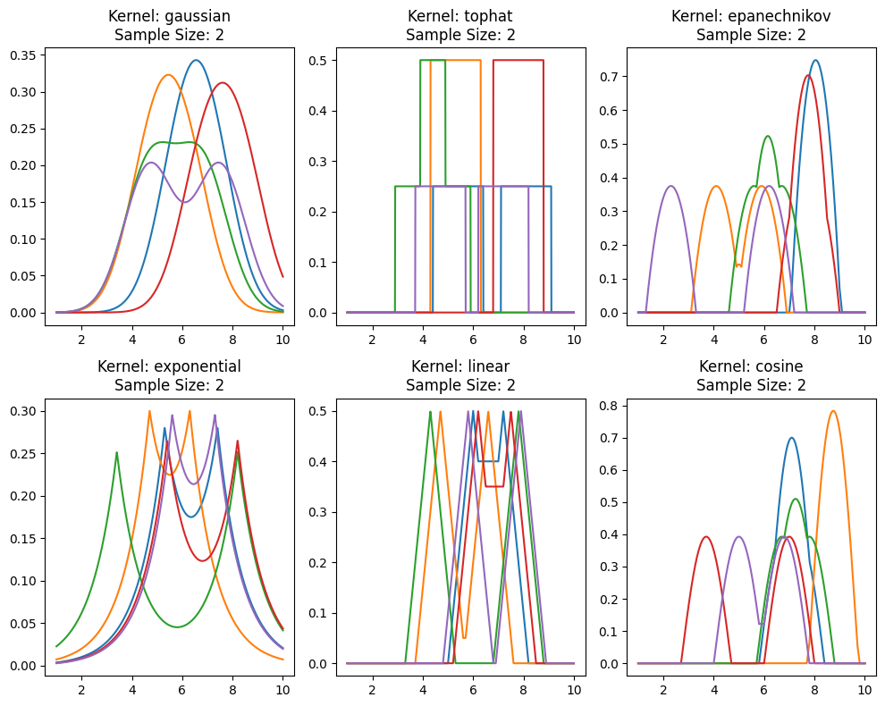

```python
# YOUR SOLUTION HERE
kernel_types = ['gaussian', 'tophat', 'epanechnikov', 'exponential', 'linear', 'cosine']

fig, axs = plt.subplots(2, 3, figsize=(10, 8))

for idx, kernel in enumerate(kernel_types, 1):
    plt.subplot(2, 3, idx)
    for _ in range(5):
        sample = np.array(movies['IMDB_Rating'].sample(2))
        sample = sample[~np.isnan(sample)]
        sample = sample.reshape(-1, 1)
        kde = KernelDensity(kernel=kernel).fit(sample)
        log_density = kde.score_samples(X_plot)
        plt.plot(X_plot[:, 0], np.exp(log_density), '-')
    plt.title(f"Kernel: {kernel}\nSample Size: 2")

plt.tight_layout()
plt.show()
```

**Q: Let's use Seaborn again. We can play with the bandwidth option. Make sure to set the `xlim` so that all plots have the same x range, so that we can compare.**

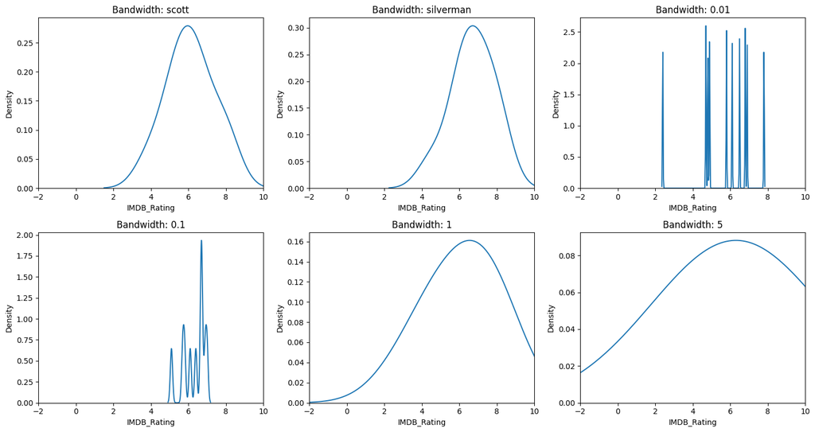

```python
f = plt.figure(figsize=(15,8))
bw = ['scott', 'silverman', 0.01, 0.1, 1, 5]
sample_size = 10

# YOUR SOLUTION HERE

for i, bandwidth in enumerate(bw, 1):
    plt.subplot(2, 3, i)
    plt.title(f"Bandwidth: {bandwidth}")
    sns.kdeplot(data=movies['IMDB_Rating'].sample(sample_size), bw_method=bandwidth)
    plt.xlim(-2, 10)

plt.tight_layout()
plt.show()
```

**Q: What's your takeaway? Explain how bandwidth affects the result of your visualization.**

```python
# YOUR SOLUTION HERE
```

The selection of bandwidth in Kernel Density Estimation (KDE) holds substantial influence over the form and smoothness of the estimated probability density function. Below, we delve into how varying bandwidth values impact the visualization:

Scott's Rule and Silverman's Rule (bw='scott' and bw='silverman'): These are automatic bandwidth selection methods that gauge bandwidth based on the distribution of the data. They tend to yield KDE plots that are notably smooth and well-balanced.

Small Bandwidths (e.g., 0.01 and 0.1): Opting for smaller bandwidths results in KDEs that are narrow and peaked. These KDEs closely track the data points, potentially leading to overfitting.

Large Bandwidth (bw=5): A larger bandwidth setting generates a very smooth and broad KDE. This can oversmooth the data and obscure vital local variations or bimodal characteristics within the distribution.

In conclusion, the choice of bandwidth involves a trade-off between capturing fine-grained details in the data (small bandwidth) and creating a smooth, generalized representation (large bandwidth). The ideal bandwidth choice hinges on the specific dataset and the objectives of the analysis.

## Interpolation

One area where interpolation is used a lot is image processing. Play with it!

https://matplotlib.org/examples/images_contours_and_fields/interpolation_methods.html

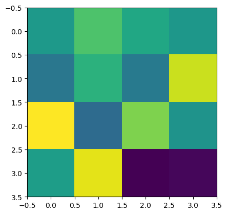

```python
methods = [None, 'none', 'nearest', 'bilinear', 'bicubic', 'spline16',
           'spline36', 'hanning', 'hamming', 'hermite', 'kaiser', 'quadric',
           'catrom', 'gaussian', 'bessel', 'mitchell', 'sinc', 'lanczos']
np.random.seed(0)
grid = np.random.rand(4, 4)

plt.imshow(grid, interpolation=None, cmap='viridis')
```

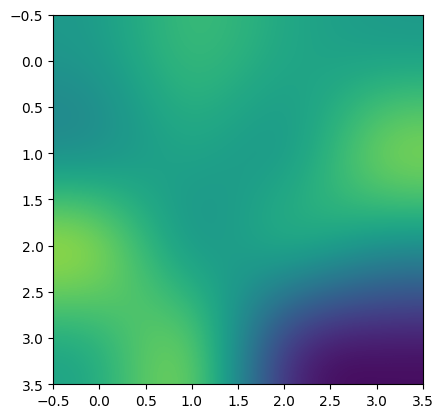

```python
plt.imshow(grid, interpolation='bicubic', cmap='viridis')
```

Let's look at some time series data.

```python
co2 = vega_datasets.data.co2_concentration()
co2.head()
```

|  | Date | CO2 |
| --- | --- | --- |
| 0 | 1958-03-01 | 315.70 |
| 1 | 1958-04-01 | 317.46 |
| 2 | 1958-05-01 | 317.51 |
| 3 | 1958-07-01 | 315.86 |
| 4 | 1958-08-01 | 314.93 |

```python
co2.Date.dtype
```

```
dtype('O')
```

The `Date` colume is stored as strings. Let's convert it to `datetime` so that we can manipulate.

```python
pd.to_datetime(co2.Date).head()
```

```
0   1958-03-01
1   1958-04-01
2   1958-05-01
3   1958-07-01
4   1958-08-01
Name: Date, dtype: datetime64[ns]
```

```python
co2.Date = pd.to_datetime(co2.Date)
```

```python
co2.set_index('Date', inplace=True)
co2.head()
```

| Date | CO2 |
| --- | --- |
| 1958-03-01 | 315.70 |
| 1958-04-01 | 317.46 |
| 1958-05-01 | 317.51 |
| 1958-07-01 | 315.86 |
| 1958-08-01 | 314.93 |

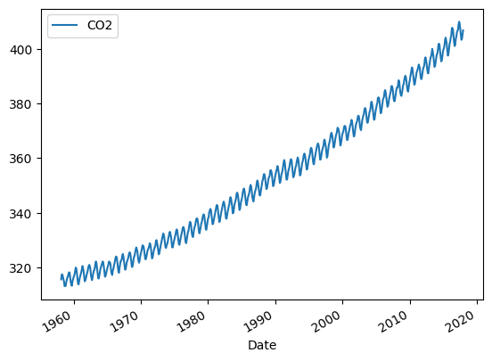

```python
co2.plot()
```

😢

```python
recent_co2 = co2.tail(8)
```

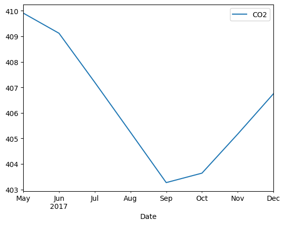

```python
recent_co2.plot()
```

This standard line chart above can be considered as a chart with linear interpolation between data points.

The data contains measurements at the resolution of about a month. Let's up-sample the data. This process create new rows that fill the gap between data points. We can use `interpolate()` function to fill the gaps.

```python
upsampled = recent_co2.resample('D')
upsampled.interpolate().head()
```

| Date | CO2 |
| --- | --- |
| 2017-05-01 | 409.910000 |
| 2017-05-02 | 409.884516 |
| 2017-05-03 | 409.859032 |
| 2017-05-04 | 409.833548 |
| 2017-05-05 | 409.808065 |

If we do `linear` interpolation, we get more or less the same plot, but just with more points.

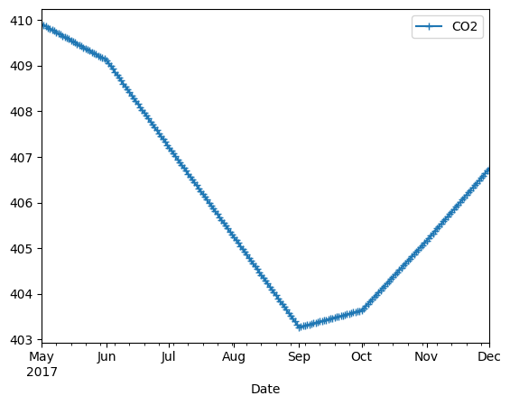

```python
recent_co2.resample('D').interpolate(method='linear').plot(style='+-')
```

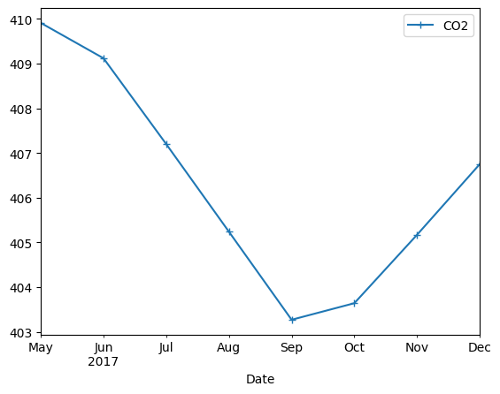

```python
recent_co2.plot(style='+-')
```

`Nearest` interpolation is just a process of assigning the nearest value to each missing rows.

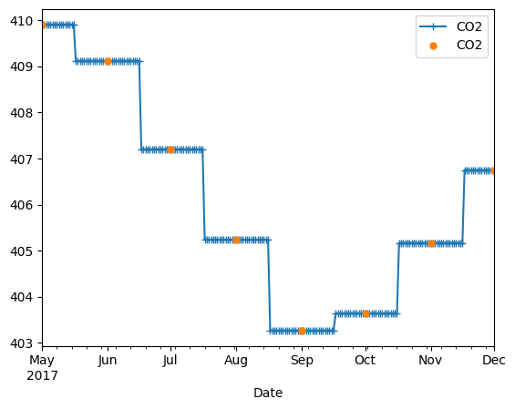

```python
ax = recent_co2.resample('D').interpolate(method='nearest').plot(style='+-')
recent_co2.plot(ax=ax, style='o', ms=5)
```

Let's try a spline too.

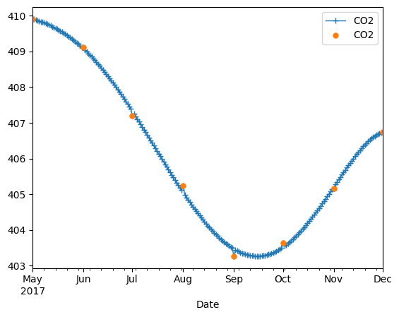

```python
ax = recent_co2.resample('D').interpolate(method='spline', order=5).plot(style='+-', lw=1)
recent_co2.plot(ax=ax, style='o', ms=5)
```

## Moving average

Pandas has a nice method called `rolling()`: https://pandas.pydata.org/pandas-docs/stable/generated/pandas.DataFrame.rolling.html

It lets you do operations on the `rolling` windows. For instance, if you want to calculate the moving average, you can simply

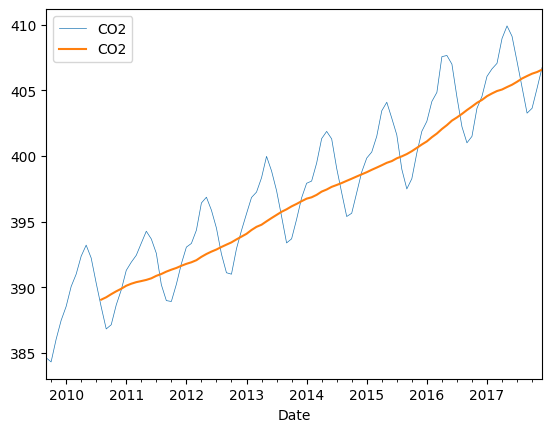

```python
ax = co2[-100:].plot(lw=0.5)
co2[-100:].rolling(12).mean().plot(ax=ax)
```

By default, it consider every data point inside each window equally (`win_type=None`) but there are many window types supported by `scipy`. Also by default, the mean value is put at the right end of the window (trailing average).

**Q: can you create a plot with `triang` window type and centered average?**

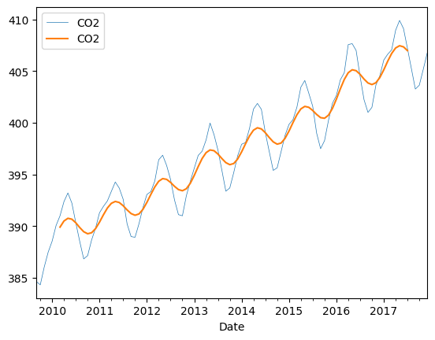

```python
# YOUR SOLUTION HERE
ax = co2[-100:].plot(lw=0.5)
co2[-100:].rolling(12, win_type='triang', center=True).mean().plot(ax=ax)
```

# Examining relationsips

Remember [Anscombe's quartet](https://en.wikipedia.org/wiki/Anscombe%27s_quartet)? Actually, the dataset is not only included in `vega_datasets` but also in `seaborn`.

```python
df = sns.load_dataset("anscombe")
df.head()
```

|  | dataset | x | y |
| --- | --- | --- | --- |
| 0 | I | 10.0 | 8.04 |
| 1 | I | 8.0 | 6.95 |
| 2 | I | 13.0 | 7.58 |
| 3 | I | 9.0 | 8.81 |
| 4 | I | 11.0 | 8.33 |

All four datasets are in this single data frame and the 'dataset' indicator is one of the columns. This is a form often called [tidy data](http://vita.had.co.nz/papers/tidy-data.pdf), which is easy to manipulate and plot. In tidy data, each row is an observation and columns are the properties of the observation. Seaborn makes use of the tidy form. Using seaborn's `lmplot`, you can very quickly examine relationships between variables, separated by some facets of the dataset.

**Q: Can you produce the plot below using `lmplot()`?**

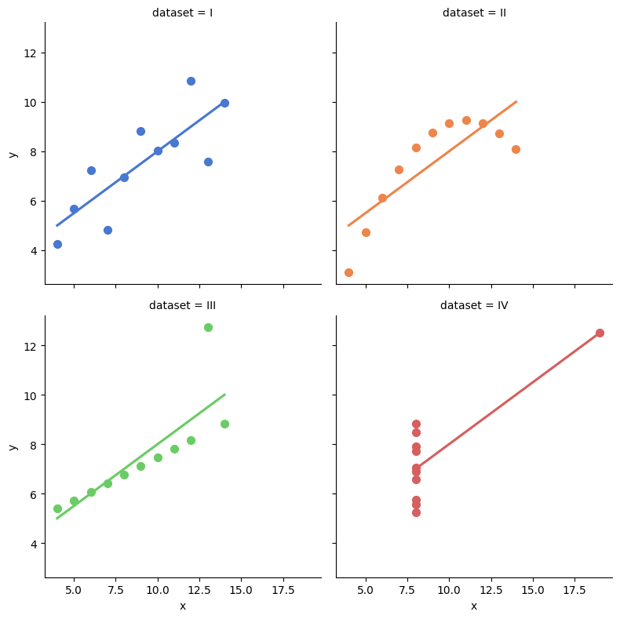

```python
# plotting parameters you can use
palette = "muted"
scatter_kws={"s": 50, "alpha": 1}
ci=None
height=4

# Implement

# YOUR SOLUTION HERE

g = sns.lmplot(x="x", y="y", hue="dataset", data=df, palette=palette, scatter_kws=scatter_kws, ci=ci, height=height, col="dataset", col_wrap=2)
plt.show()
```

**Q: So let's look at the relationship between `IMDB_Rating` and `Rotten_Tomatoes_Rating` in the `movies` dataset, separated with respect to `MPAA_Rating`. Put 4 plots in a row.**

[figure not shown]

```python
# YOUR SOLUTION HERE

g = sns.lmplot(x="IMDB_Rating", y="Rotten_Tomatoes_Rating", hue="MPAA_Rating", data=movies,
               height=4, col="MPAA_Rating", col_wrap=4, palette="muted", scatter_kws={"s": 5, "alpha": 0.5})

g.set_axis_labels("IMDB Rating", "Rotten Tomatoes Rating")
g.set_titles(col_template="{col_name} MPAA Rating")
plt.show()
```

It may be interesting to dig up what are the movies that have super high Rotten Tomatoes rating and super low IMDB rating (and vice versa)!

Another useful method for examining relationships is [**`jointplot()`**](http://stanford.edu/~mwaskom/software/seaborn/generated/seaborn.jointplot.html), which produces a scatter plot with two marginal histograms.

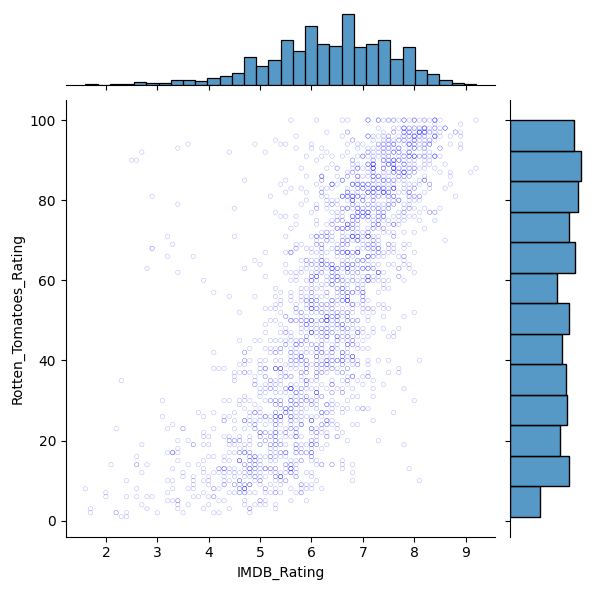

```python
g = sns.jointplot(x = movies['IMDB_Rating'], y = movies['Rotten_Tomatoes_Rating'], s=10, alpha=0.4, facecolors='none', edgecolor='b')
```

## Hexbin density plot

In 2D, *heatmap* can be considered as a color-based histogram. You divide the space into bins and show the frequency with colors. A common binning method is the hexagonal bin.

We can again use the [**`jointplot()`**](http://stanford.edu/~mwaskom/software/seaborn/generated/seaborn.jointplot.html) and setting the `kind` to be `hexbin`.

**Q: Can you create one?**

[figure not shown]

```python
# YOUR SOLUTION HERE

g = sns.jointplot(x=movies['IMDB_Rating'], y=movies['Rotten_Tomatoes_Rating'], kind='hex', gridsize=20, cmap='Blues', alpha = 1)
g.set_axis_labels('IMDB Rating', 'Rotten Tomatoes Rating')
plt.show()
```

## 2D KDE

We can also do 2D KDE using seaborn's [**`kdeplot()`**](https://stanford.edu/~mwaskom/software/seaborn/generated/seaborn.kdeplot.html) function.

**Q: Can you draw one like this?**

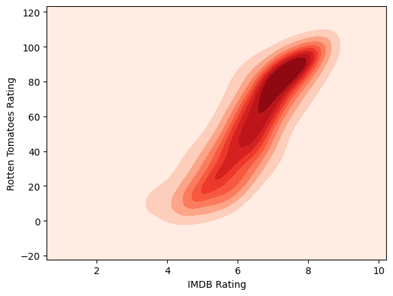

```python
cmap = "Reds"
fill = True       # what happens if you change this?
thresh = 0       # what happens if you change this?

# YOUR SOLUTION HERE
sns.kdeplot(x=movies['IMDB_Rating'], y=movies['Rotten_Tomatoes_Rating'], cmap=cmap, fill=fill, thresh=thresh)
plt.xlabel('IMDB Rating')
plt.ylabel('Rotten Tomatoes Rating')
plt.show()
```

**ANSWER -**

if fill = True is changed to fill = False, there is no colour inside the plot, just borders.

if thresh is set to 1 instead of 0, it throws an error - "ValueError: Contour levels must be increasing"

Or again using [**`jointplot()`**](http://stanford.edu/~mwaskom/software/seaborn/generated/seaborn.jointplot.html) by setting the `kind` parameter. Look, we also have the 1D marginal KDE plots!

**Q: create jointplot with KDE**

Note that the X-axis is logarithm of `IMDB_Votes`.

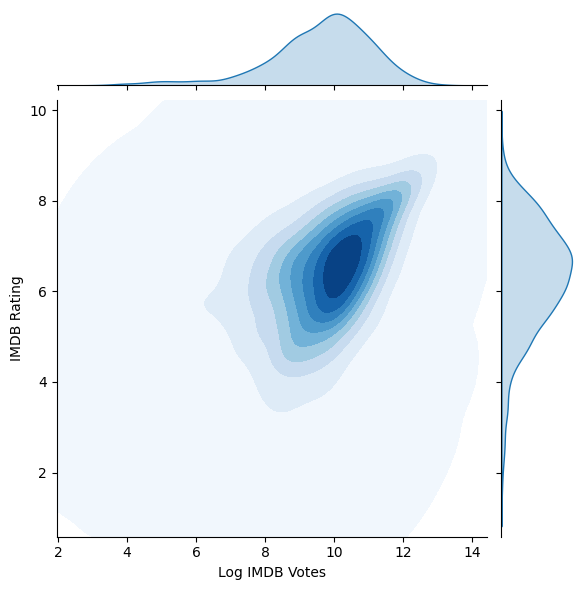

```python
# YOUR SOLUTION HERE

movies['Log_IMDB_Votes'] = np.log(movies['IMDB_Votes'])
g = sns.jointplot(x='Log_IMDB_Votes', y='IMDB_Rating', data=movies, kind='kde', cmap='Blues', fill = True, thresh=0, alpha = 1)
g.set_axis_labels('Log IMDB Votes', 'IMDB Rating')
plt.show()
```